# Reproducible Research Project 1

First step is to load dataset and remove NA values

```r
Fitdata <- na.omit(read.csv("123.csv", header = TRUE))
```

Question 1 - What is the mean steps taken per day?

Calc the number of steps taken per day and display in a histogram

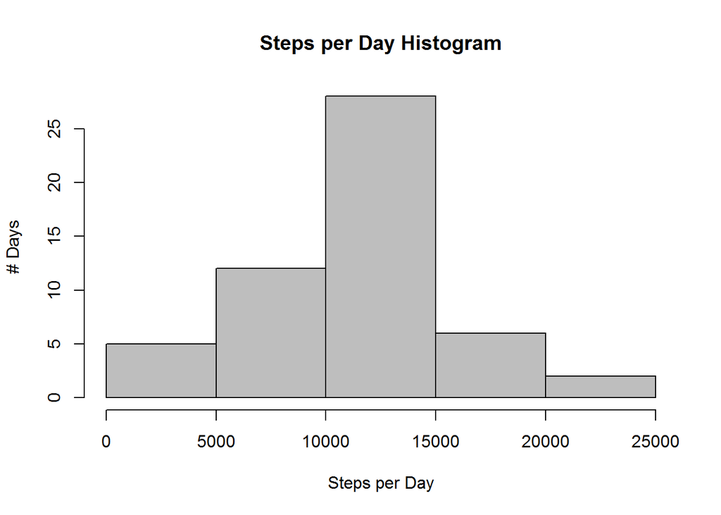

```r
datastepspd <- aggregate(steps~date, Fitdata, sum)
hist(datastepspd$steps, xlab = "Steps per Day", ylab = "# Days", main = "Steps per Day Histogram", col = 72)
```

What are the mean and median steps taken per day?

```r
meanstepsperday <-mean(datastepspd$steps)
medianstepsperday <- median(datastepspd$steps)
meanstepsperday
```

```
## [1] 10766.19
```

```r
medianstepsperday
```

```
## [1] 10765
```

Question 2 - What is the average daily activity patern?

[figure not shown]

```r
datastepspint <- aggregate(steps~interval, Fitdata, sum)
stepsperintplot <- plot(datastepspint$interval, datastepspint$steps, xlab = "Interval", ylab = "# Steps", main = "Avg Steps Over Intervals", pch=1,col=580)
axis(1, at = seq(0,2400, by=100), las=3)
```

Which 5 minute interval on average contains the most steps?

```r
moststeps <- datastepspint[which(datastepspint$steps == max(datastepspint$steps)),]
moststeps
```

```
##     interval steps
## 104      835 10927
```

Question 3 - Imputing missing values

Calculate and report the total number of missing values in the dataset - for this will have to reload the data and the calc the number of NAs

```r
fitdatana <- read.csv("123.csv", header = TRUE)
nasindata <-sum(is.na(fitdatana))
nasindata
```

```
## [1] 2304
```

Create new data set equal to original one with blanks filled in and determine method to replace the NAs. For this will simply replace NAs with the mean of dataset

```r
fitdatana1 <- fitdatana
fitdatana1$steps[which(is.na(fitdatana1$steps))] <- mean(fitdatana1$steps, na.rm = TRUE)
```

Make histogram of total steps per day and calc mean and median total steps per day

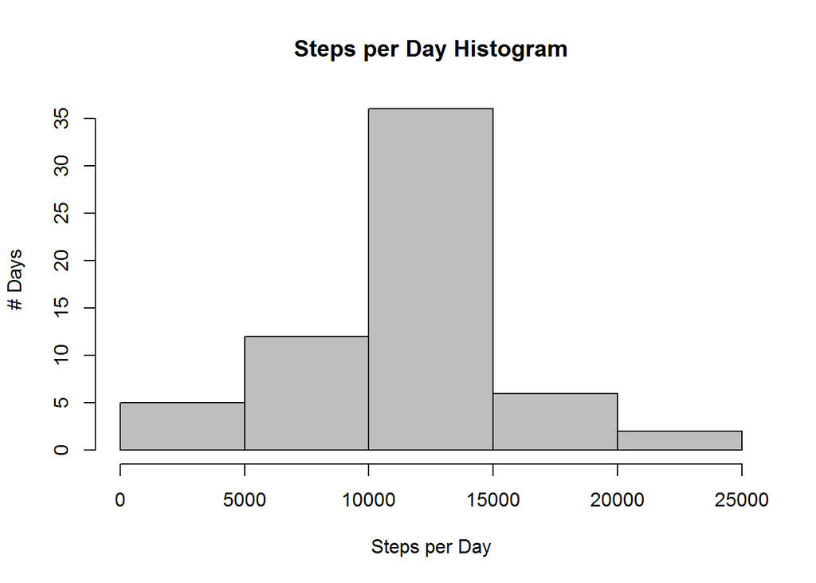

```r
datastepspd1 <- aggregate(steps~date, fitdatana1, sum)
hist(datastepspd1$steps, xlab = "Steps per Day", ylab = "# Days", main = "Steps per Day Histogram", col = 72)
```

```r
meanstepsperday1 <- mean(datastepspd1$steps)
medianstepsperday1 <- median(datastepspd1$steps)
meanstepsperday1
```

```
## [1] 10766.19
```

```r
medianstepsperday1
```

```
## [1] 10766.19
```

Question 4 - Are there differnces in activity patterns between weekdays and weekends

```r
fitdatana2 <- fitdatana1
fitdatana2$date <- as.Date(fitdatana2$date)
fitdatana2$dow <-as.Date(fitdatana2$date)
weekdays1 <- c('Monday', 'Tuesday', 'Wednesday', 'Thursday', 'Friday')
fitdatana2$dow <- factor((weekdays(fitdatana2$date) %in% weekdays1),
                   levels=c(FALSE, TRUE), labels=c('weekday', 'weekend'))
```

[figure not shown]

```r
library(lattice)
xyplot(fitdatana2$steps ~ fitdatana2$interval|fitdatana2$dow, main="Average Steps per Day by Interval",xlab="Interval", ylab="Steps",layout=c(1,2), type="l")
```